# Project7-Draft7

Cluster 1:  
Mid-range credit limit between 10k and 52k.  
Mid-range amount of cards between 4 and 6 cards.  
Highest number of bank visits 3-5.  
Lowest online visits 0-2.  
Low calls made 1-3. These customers prefer to come into the bank to handle issues. They rarely go online or make calls. Up-selling should be done in the bank.

Cluster 2:  
Highest credit limit 110k-170k.  
Highest number of cards 8-10.  
Low number of bank visits 0-1.  
Highest number of online visits 8-13. Lowest calls made 0-2. These customers rarely come in to the bank locations or call. They prefer to handle issues online. Up-selling these customers should be done online.

```python
all_col
```

```
['Avg_Credit_Limit',
 'Total_Credit_Cards',
 'Total_visits_bank',
 'Total_visits_online',
 'Total_calls_made']
```

```python
scaler=StandardScaler()
subset=data[all_col].copy()
subset_scaled=scaler.fit_transform(subset)
```

```python
subset_scaled_data=pd.DataFrame(subset_scaled,columns=subset.columns)
```

```python
distance_metrics = [ 'euclidean','chebyshev','mahalanobis','cityblock']
linkage_methods = ['single', 'complete', 'average', 'weighted']
high_cophenet_corr = 0
high_dm_lm = [0,0]
for dm in distance_metrics:
    for lm in linkage_methods:
        Z = linkage(subset_scaled_data, metric=dm, method=lm)
        c, coph_dists = cophenet(Z , pdist(subset_scaled_data))
        print('Cophent correlation for distance metrics {} and linkage method {} is {}'.format(dm,lm,c))
        if high_cophenet_corr < c:
            high_cophenet_corr = c
            high_dm_lm[0] = dm
            high_dm_lm[1] = lm
```

```
Cophent correlation for distance metrics euclidean and linkage method single is 0.7391220243806552
Cophent correlation for distance metrics euclidean and linkage method complete is 0.8599730607972423
Cophent correlation for distance metrics euclidean and linkage method average is 0.8977080867389372
Cophent correlation for distance metrics euclidean and linkage method weighted is 0.8861746814895477
Cophent correlation for distance metrics chebyshev and linkage method single is 0.7382354769296767
Cophent correlation for distance metrics chebyshev and linkage method complete is 0.8533474836336782
Cophent correlation for distance metrics chebyshev and linkage method average is 0.8974159511838106
Cophent correlation for distance metrics chebyshev and linkage method weighted is 0.8913624010768603
Cophent correlation for distance metrics mahalanobis and linkage method single is 0.7058064784553607
Cophent correlation for distance metrics mahalanobis and linkage method complete is 0.6663534463875355
Cophent correlation for distance metrics mahalanobis and linkage method average is 0.8326994115042136
Cophent correlation for distance metrics mahalanobis and linkage method weighted is 0.7805990615142518
Cophent correlation for distance metrics cityblock and linkage method single is 0.7252379350252723
Cophent correlation for distance metrics cityblock and linkage method complete is 0.8731477899179829
Cophent correlation for distance metrics cityblock and linkage method average is 0.896329431104133
Cophent correlation for distance metrics cityblock and linkage method weighted is 0.8825520731498188
```

```python
print('Highest cophenet correlation is {}, which is obtained with {} distance metric and {} linkage method'.format(high_cophenet_corr ,high_dm_lm[0],high_dm_lm[1]))
```

```
Highest cophenet correlation is 0.8977080867389372, which is obtained with euclidean distance metric and average linkage method
```

```python
pd.crosstab(data.K_means_segments, data.Avg_Credit_Limit).style.highlight_max(color = 'lightgreen', axis = 0)
```

| Avg_Credit_Limit K_means_segments | 3000 | 5000 | 6000 | 7000 | 8000 | 9000 | 10000 | 11000 | 12000 | 13000 | 14000 | 15000 | 16000 | 17000 | 18000 | 19000 | 20000 | 25000 | 26000 | 27000 | 28000 | 29000 | 30000 | 31000 | 32000 | 33000 | 34000 | 35000 | 36000 | … |
| --- | --- | --- | --- | --- | --- | --- | --- | --- | --- | --- | --- | --- | --- | --- | --- | --- | --- | --- | --- | --- | --- | --- | --- | --- | --- | --- | --- | --- | --- | --- |
| 0 | 0 | 8 | 14 | 11 | 15 | 10 | 12 | 9 | 10 | 10 | 9 | 6 | 9 | 10 | 14 | 13 | 7 | 1 | 5 | 2 | 3 | 5 | 6 | 5 | 2 | 4 | 6 | 2 | 11 | … |
| 1 | 1 | 13 | 17 | 13 | 20 | 18 | 14 | 15 | 8 | 18 | 14 | 11 | 13 | 13 | 9 | 13 | 13 | 0 | 0 | 0 | 0 | 0 | 0 | 0 | 0 | 0 | 0 | 0 | 0 | … |
| 2 | 0 | 0 | 0 | 0 | 0 | 0 | 0 | 0 | 0 | 0 | 0 | 0 | 0 | 0 | 0 | 0 | 0 | 0 | 0 | 0 | 0 | 0 | 0 | 0 | 0 | 0 | 0 | 0 | 0 | … |

```python
linkage_methods = ['single', 'complete', 'average','median','ward', 'weighted']
high_cophenet_corr = 0
high_dm_lm = [0,0]

for lm in linkage_methods:
    Z = linkage(subset_scaled_data, metric='euclidean', method=lm)
    c, coph_dists = cophenet(Z , pdist(subset_scaled_data))
    print('Cophent correlation for distance metrics {} and linkage method {} is {}'.format('euclidean',lm,c))
    if high_cophenet_corr < c:
        high_cophenet_corr = c
        high_dm_lm[0] = dm
        high_dm_lm[1] = lm
print('*'*110)
print('Highest cophenet correlation is {}, which is obtained with {} distance metric and {} linkage method'.format(high_cophenet_corr ,high_dm_lm[0],high_dm_lm[1]))
```

```
Cophent correlation for distance metrics euclidean and linkage method single is 0.7391220243806552
Cophent correlation for distance metrics euclidean and linkage method complete is 0.8599730607972423
Cophent correlation for distance metrics euclidean and linkage method average is 0.8977080867389372
Cophent correlation for distance metrics euclidean and linkage method median is 0.8893799537016724
Cophent correlation for distance metrics euclidean and linkage method ward is 0.7415156284827493
Cophent correlation for distance metrics euclidean and linkage method weighted is 0.8861746814895477
Highest cophenet correlation is 0.8977080867389372, which is obtained with cityblock distance metric and average linkage method
```

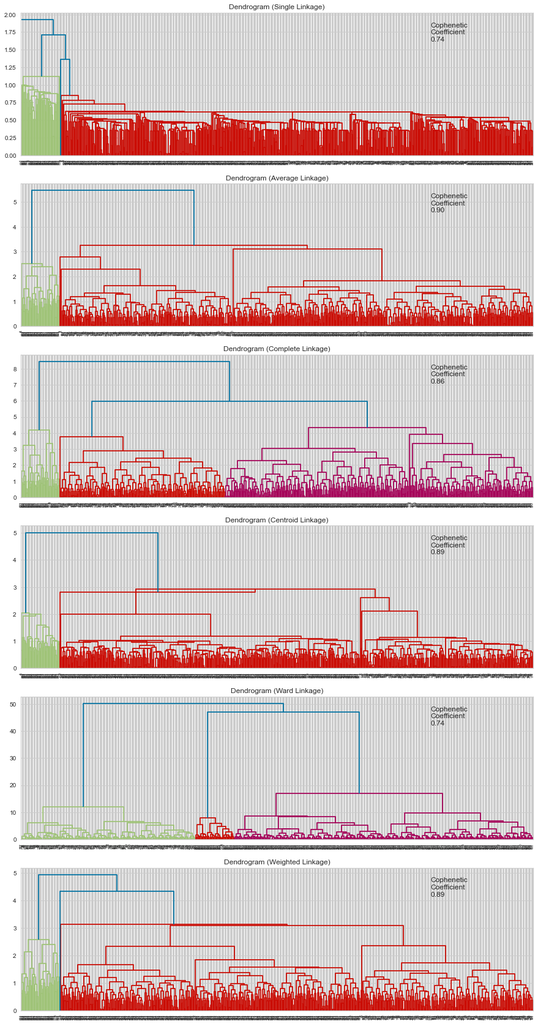

```python
methods = ['single',
           'average',
           'complete',
           'centroid',
           'ward',
          'weighted']


compare_cols = ['Linkage', 'Cophenetic Coefficient']
compare = []


fig, axs = plt.subplots(len(methods), 1, figsize=(15, 30))


for i, method in enumerate(methods):

    Z = linkage(subset_scaled_data, metric='euclidean', method=method)

    dendrogram(Z, ax=axs[i]);
    axs[i].set_title(f'Dendrogram ({method.capitalize()} Linkage)')
    coph_corr, coph_dist = cophenet(Z, pdist(subset_scaled_data))
    axs[i].annotate(f'Cophenetic\nCoefficient\n{coph_corr:0.2f}',
                    (0.80, 0.80),
                    xycoords='axes fraction')
    compare.append([method, coph_corr])
```

Complete linkage appears to show 3 distinct clusters.

```python
df_cc = pd.DataFrame(compare, columns=compare_cols)
df_cc
```

|  | Linkage | Cophenetic Coefficient |
| --- | --- | --- |
| 0 | single | 0.739122 |
| 1 | average | 0.897708 |
| 2 | complete | 0.859973 |
| 3 | centroid | 0.893939 |
| 4 | ward | 0.741516 |
| 5 | weighted | 0.886175 |

```python
distance_metrics = [ 'euclidean','cityblock']
linkage_methods = ['complete', 'weighted']
```

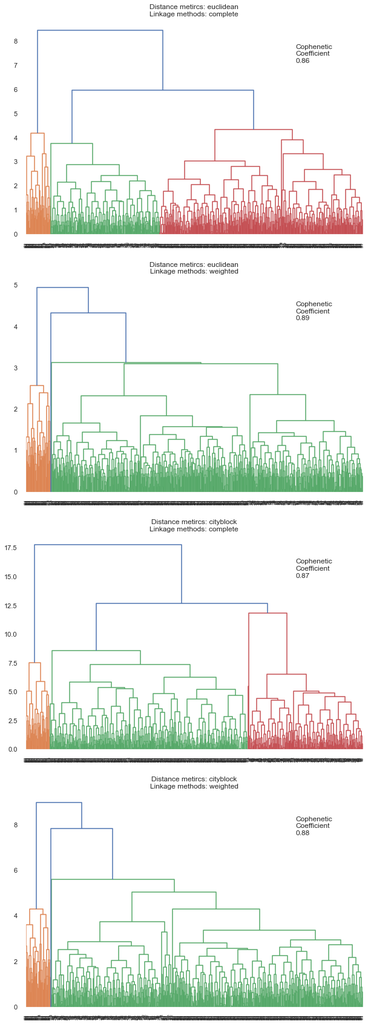

```python
fig, axs = plt.subplots(len(distance_metrics)+len(distance_metrics), 1, figsize=(10, 30))
i=0
for dm in distance_metrics:
    for lm in linkage_methods:
        Z = linkage(subset_scaled_data, metric=dm, method=lm)
        dendrogram(Z,  ax=axs[i]);
        axs[i].set_title('Distance metircs: {}\nLinkage methods: {}'.format(dm,lm))
        coph_corr, coph_dist = cophenet(Z, pdist(subset_scaled_data))
        axs[i].annotate(f'Cophenetic\nCoefficient\n{coph_corr:0.2f}',
                        (0.80, 0.80),
                        xycoords='axes fraction')
        axs[i].set_title('Distance metircs: {}\nLinkage methods: {}'.format(dm,lm))
        i +=1
```

Cityblock Complete shows 3 distict clusters.

```python
HCmodel = AgglomerativeClustering(n_clusters=3,affinity='cityblock', linkage='complete')
HCmodel.fit(subset_scaled_data)
subset_scaled_data['HC_Clusters'] = HCmodel.labels_
```

```python
data['HC_Clusters'] = HCmodel.labels_
```

```python
cluster_profile = data.groupby('HC_Clusters').mean()
```

```python
cluster_profile['count_in_each_segments'] = data.groupby('HC_Clusters')['Avg_Credit_Limit'].count().values
```

```python
cluster_profile.style.highlight_max(color = 'lightgreen', axis = 0)
```

| HC_Clusters | Avg_Credit_Limit | Total_Credit_Cards | Total_visits_bank | Total_visits_online | Total_calls_made | K_means_segments | count_in_each_segments |
| --- | --- | --- | --- | --- | --- | --- | --- |
| 0 | 12977.777778 | 2.431111 | 0.920000 | 3.631111 | 6.844444 | 1.008889 | 225 |
| 1 | 142750.000000 | 8.875000 | 0.625000 | 10.875000 | 1.020833 | 2.000000 | 48 |
| 2 | 33713.178295 | 5.511628 | 3.485788 | 0.984496 | 2.005168 | 0.002584 | 387 |

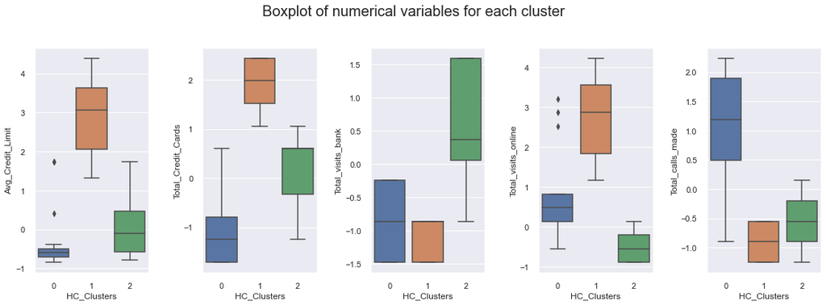

```python
fig, axes = plt.subplots(1, 5,  figsize=(16, 6))
fig.suptitle('Boxplot of numerical variables for each cluster', fontsize=20)
counter = 0
for ii in range(5):
    sns.boxplot(ax=axes[ii],y=subset_scaled_data[all_col[counter]],x=subset_scaled_data['HC_Clusters'])
    counter = counter+1

fig.tight_layout(pad=2.0)
```

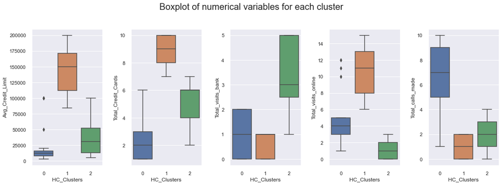

```python
fig, axes = plt.subplots(1, 5,  figsize=(16, 6))
fig.suptitle('Boxplot of numerical variables for each cluster', fontsize=20)
counter = 0
for ii in range(5):
    sns.boxplot(ax=axes[ii],y=data[all_col[counter]],x=data['HC_Clusters'])
    counter = counter+1

fig.tight_layout(pad=2.0)
```

Cluster 0:  
Lowest credit limit 10k-20k.  
Lowest number of credit cards 1-3.  
Low bank visit 0-2.  
Low online visits 2-4. Highest calls made 5-9. These customers rarely come into the bank or get online. They prefer to call to handle issues. Upsaling to these should be done via phone.

Cluster 1:  
Highest credit limit 110k-170k.  
Highest number of cards 8-10.  
Low number of bank visits 0-1.  
Highest number of online visits 8-13. Lowest calls made 0-2. These customers rarely come in to the bank locations or call. They prefer to handle issues online. Upsaling these customers should be done online.

Cluster 2:  
Mid-range credit limit between 10k and 52k.  
Mid-range amount of cards between 4 and 6 cards.  
Highest number of bank visits 3-5.  
Lowest online visits 0-2.  
Low calls made 1-3. These customers prefer to come into the bank to handle issues. They rarely go online or make calls. Upsaling should be done in the bank.